# Project Al-Huda

# **Al-Quran** - *An Introduction*

**Al-Quran** is the last holy book to have been revealed to mankind by Allah almighty. It is known by many names and is revered by the entire Muslim world as the word of the Creator. Prophet Muhammad (SAW) received this text through angel Jibrael (Gabriel) and it was later written by his companions. It is the last divine book which was revealed to the last Prophet (SAW). The revelation is in Arabic language and despite being 1400 years old it’s language is still fresh and recognized.

The text is divided into 114 chapters known as Surahs. These surahs are categorized as Meccan and Medinan based on their location of revelation to Prophet Muhammad (SAW). Furthermore the ayahs in surahs are grouped into rakus.

## Objectives

The goal of this project is to study Al-Quran from the perspective of a data scientist and explore the tools of R language along the way.

## Required Data

**Al-Quran text**

- Obtained from [Al-Quran Cloud API](https://alquran.cloud/api). The obtained files are in JSON formatand include metadata along with the required text. Further info can be obtained from referenced API endpoint.

In order to simplify, after reading the API documentation, I reduced the dataset and only included the following :

- Arabic Uthmani Text
- Simplified Arabic Text
- English Translation (Saheeh International)
- Surah list containing Surah metadata

## First Steps and Loading up Data

In order to load up JSON data as an R dataframe I used `jsonlite`.

```r
Surahs <- fromJSON("surat.json")
Surahs<-Surahs$surat # The actual data is in the sub-object "surat"
#fatiha<-Q[1]$surat[1]
```

We get surah list as `Surahs`. Let’s see what does this variable contains.

```r
str(Surahs)
```

```
## 'data.frame':    114 obs. of  6 variables:
##  $ id                : int  1 2 3 4 5 6 7 8 9 10 ...
##  $ name              : chr  "سورة الفاتحة" "سورة البقرة" "سورة آل عمران" "سورة النساء" ...
##  $ englishname       : chr  "Al-Faatiha" "Al-Baqara" "Aal-i-Imraan" "An-Nisaa" ...
##  $ englishtranslation: chr  "The Opening" "The Cow" "The Family of Imraan" "The Women" ...
##  $ revelationCity    : chr  "Meccan" "Medinan" "Medinan" "Medinan" ...
##  $ numberOfAyats     : int  7 286 200 176 120 165 206 75 129 109 ...
```

```r
summary(Surahs)
```

```
##        id             name           englishname        englishtranslation
##  Min.   :  1.00   Length:114         Length:114         Length:114
##  1st Qu.: 29.25   Class :character   Class :character   Class :character
##  Median : 57.50   Mode  :character   Mode  :character   Mode  :character
##  Mean   : 57.50
##  3rd Qu.: 85.75
##  Max.   :114.00
##  revelationCity     numberOfAyats
##  Length:114         Min.   :  3.00
##  Class :character   1st Qu.: 15.50
##  Mode  :character   Median : 39.00
##                     Mean   : 54.70
##                     3rd Qu.: 77.75
##                     Max.   :286.00
```

The dataframe contains the following details :

Now is the time for data cleanup, however at the moment all I can think of is converting `revelationCity` to factor instead of char.

```r
Surahs$revelationCity<-as.factor(Surahs$revelationCity)
#str(Surahs)
```

## Plotting Surahs

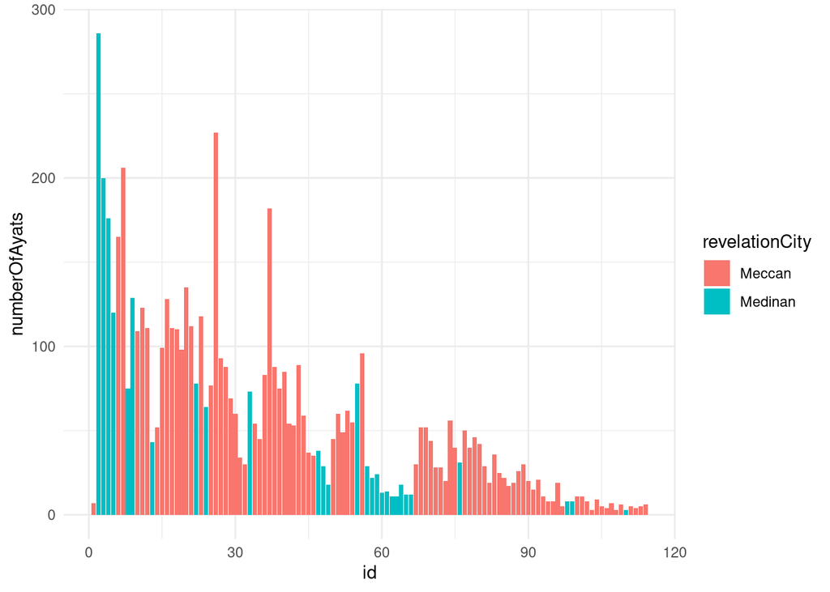

```r
ggplot(data=Surahs,aes(x=id,y=numberOfAyats,fill=revelationCity))+
  geom_bar(stat="identity")+
  #geom_text(aes(label=name), color="black", size=5.5)+
  theme_minimal()
```

This is our first plot. On the X-axis the `id` represents the ser no of the surahs from 1 to 114. On the Y-axis the `numberOfAyats` controls the bar height. The colors of the bars indicate `revelationCity`, either **Meccan** or **Medinan**.

This marks the end of first session.